# Yifan_Wu_HW2.Rmd

Yifan Wu

February 3, 2018

# 3.7.4

## (a).

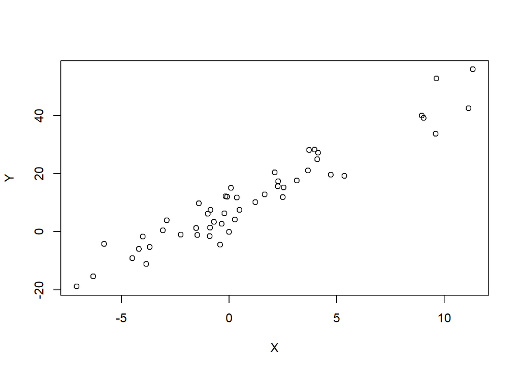

```r
true_beta_0 = 8
true_beta_1 = 3.5

x<-rnorm(50, 0, 5)
y <- true_beta_1 * x + true_beta_0 + rnorm(50,0,5)

df <- data.frame(X = x,Y = y)
plot(df$X, df$Y, xlab="X", ylab="Y")
```

```r
fit <- lm(Y ~ X , df)
summary(fit)
```

```
##
## Call:
## lm(formula = Y ~ X, data = df)
##
## Residuals:
##      Min       1Q   Median       3Q      Max
## -11.0599  -3.1661  -0.9037   4.1700  10.5400
##
## Coefficients:
##             Estimate Std. Error t value Pr(>|t|)
## (Intercept)   7.9816     0.7163   11.14  6.5e-15 ***
## X             3.5507     0.1594   22.28  < 2e-16 ***
## ---
## Signif. codes:  0 '***' 0.001 '**' 0.01 '*' 0.05 '.' 0.1 ' ' 1
##
## Residual standard error: 4.933 on 48 degrees of freedom
## Multiple R-squared:  0.9118, Adjusted R-squared:   0.91
## F-statistic: 496.5 on 1 and 48 DF,  p-value: < 2.2e-16
```

```r
fit2 <- lm(Y ~ X + I(X^2) + I(X^3) , df)
summary(fit2)
```

```
##
## Call:
## lm(formula = Y ~ X + I(X^2) + I(X^3), data = df)
##
## Residuals:
##     Min      1Q  Median      3Q     Max
## -10.759  -3.243  -0.636   3.913   9.834
##
## Coefficients:
##               Estimate Std. Error t value Pr(>|t|)
## (Intercept)  7.6378935  0.9268175   8.241 1.31e-10 ***
## X            3.4527528  0.3296447  10.474 9.14e-14 ***
## I(X^2)       0.0226409  0.0497372   0.455    0.651
## I(X^3)      -0.0001248  0.0064247  -0.019    0.985
## ---
## Signif. codes:  0 '***' 0.001 '**' 0.01 '*' 0.05 '.' 0.1 ' ' 1
##
## Residual standard error: 5.008 on 46 degrees of freedom
## Multiple R-squared:  0.9129, Adjusted R-squared:  0.9073
## F-statistic: 160.8 on 3 and 46 DF,  p-value: < 2.2e-16
```

The residual for the cubic regression model will be smaller than that of the simple linear regression. Since the higher the degree of fitted polynomial, the more likely it is to overfit the data. For a regression line that the highest degree is 3 instead of 1, it will wiggle more to accomodate as many data point as possible by minimizing RSS.

From the above simulation we can see that, the residual for the cubic polynomial regression is smaller than that of the simple linear model.

## (b).

By using test, we assume the null hypothesis that the $\beta_{i}$ vectors is a zero vector: the response is independent with all the predictors. Since the true relationship between x and y is linear. The $x^2$ and $x^3$ will unsignificant in terms of predicting y. So the p-value for $x^2$ and $x^3$ will be very big, far exceeds any reasonable significant level. From our simulated data we can see that, the p-value for $x^2$ and $x^3$ is very big. But when only look at the p-value for the model, it is hard to tell which model is a better fit because they both are significant (p-value < 0.05).

## (c).

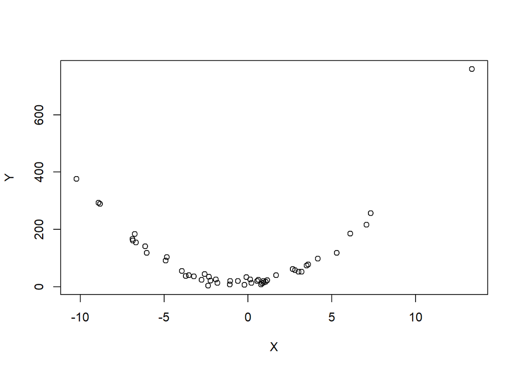

```r
true_beta_0 = 8
true_beta_1 = 4
true_beta_2 = 4

set.seed(1000)
x<-rnorm(50, 0, 5)
y <- true_beta_2 * x^2 + true_beta_1 * x + true_beta_0 + rnorm(50,0,10)

df <- data.frame(X = x,Y = y)
plot(df$X, df$Y, xlab="X", ylab="Y")
```

```r
fit <- lm(Y ~ X , df)
summary(fit)
```

```
##
## Call:
## lm(formula = Y ~ X, data = df)
##
## Residuals:
##    Min     1Q Median     3Q    Max
## -91.94 -75.63 -49.61  37.45 615.65
##
## Coefficients:
##             Estimate Std. Error t value Pr(>|t|)
## (Intercept)   97.004     18.600   5.215 3.86e-06 ***
## X              3.498      3.977   0.879    0.384
## ---
## Signif. codes:  0 '***' 0.001 '**' 0.01 '*' 0.05 '.' 0.1 ' ' 1
##
## Residual standard error: 129.6 on 48 degrees of freedom
## Multiple R-squared:  0.01586,    Adjusted R-squared:  -0.004644
## F-statistic: 0.7735 on 1 and 48 DF,  p-value: 0.3835
```

```r
fit2 <- lm(Y ~ X + I(X^2) + I(X^3) , df)
summary(fit2)
```

```
##
## Call:
## lm(formula = Y ~ X + I(X^2) + I(X^3), data = df)
##
## Residuals:
##     Min      1Q  Median      3Q     Max
## -22.743  -6.214   1.036   6.750  21.268
##
## Coefficients:
##              Estimate Std. Error t value Pr(>|t|)
## (Intercept) 12.219474   1.758813   6.948 1.09e-08 ***
## X            3.426274   0.556088   6.161 1.66e-07 ***
## I(X^2)       3.876710   0.049925  77.651  < 2e-16 ***
## I(X^3)       0.003493   0.006422   0.544    0.589
## ---
## Signif. codes:  0 '***' 0.001 '**' 0.01 '*' 0.05 '.' 0.1 ' ' 1
##
## Residual standard error: 10.1 on 46 degrees of freedom
## Multiple R-squared:  0.9943, Adjusted R-squared:  0.9939
## F-statistic:  2662 on 3 and 46 DF,  p-value: < 2.2e-16
```

For RSS, the higher the degree of the fitted polynomial is, the lower the RSS will be. The cubic model will have a lower RSS than the simple linear regression model. This is because the higher the degree is, the more wiggly the fitted line is so it can show more detail trend in the data when minimizing the RSS.

## (d).

Between using simple linear regression and cubic polynomial regression, it is not enough information to say which one can do better than the other one because the true relaitionship between response and the predictor is unknown.

Case 1: when the true relationship is quadratic:

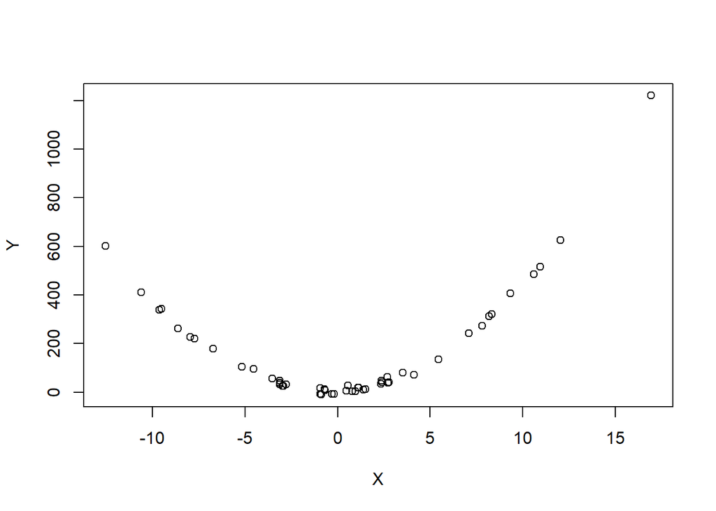

```r
true_beta_0 = 8
true_beta_1 = 3.5
true_beta_2 = 4

set.seed(1001)
x<-rnorm(50, 0, 5)
y <- true_beta_2 * x^2 + true_beta_1 * x + true_beta_0 + rnorm(50,0,10)

df <- data.frame(X = x,Y = y)
plot(df$X, df$Y, xlab="X", ylab="Y")
```

```r
fit <- lm(Y ~ X , df)
summary(fit)
```

```
##
## Call:
## lm(formula = Y ~ X, data = df)
##
## Residuals:
##     Min      1Q  Median      3Q     Max
## -166.07 -152.07  -93.02   93.25  852.37
##
## Coefficients:
##             Estimate Std. Error t value Pr(>|t|)
## (Intercept)  157.423     31.100   5.062 6.53e-06 ***
## X             12.458      5.021   2.481   0.0166 *
## ---
## Signif. codes:  0 '***' 0.001 '**' 0.01 '*' 0.05 '.' 0.1 ' ' 1
##
## Residual standard error: 219.5 on 48 degrees of freedom
## Multiple R-squared:  0.1137, Adjusted R-squared:  0.09523
## F-statistic: 6.157 on 1 and 48 DF,  p-value: 0.01664
```

```r
fit2 <- lm(Y ~ X + I(X^2) + I(X^3) , df)
summary(fit2)
```

```
##
## Call:
## lm(formula = Y ~ X + I(X^2) + I(X^3), data = df)
##
## Residuals:
##      Min       1Q   Median       3Q      Max
## -17.6503  -8.0388  -0.2392   8.7657  21.5460
##
## Coefficients:
##             Estimate Std. Error t value Pr(>|t|)
## (Intercept) 6.628713   1.891425   3.505  0.00103 **
## X           3.246073   0.451471   7.190 4.73e-09 ***
## I(X^2)      4.014341   0.033142 121.127  < 2e-16 ***
## I(X^3)      0.001590   0.003542   0.449  0.65561
## ---
## Signif. codes:  0 '***' 0.001 '**' 0.01 '*' 0.05 '.' 0.1 ' ' 1
##
## Residual standard error: 10.6 on 46 degrees of freedom
## Multiple R-squared:  0.998,  Adjusted R-squared:  0.9979
## F-statistic:  7726 on 3 and 46 DF,  p-value: < 2.2e-16
```

We can see that if the true relationship between x and y is non-linear(in our simulated case, it is quadratic), the simple linear regression tells us that although the $x$ term is significant, there still more to be discovered since the residual is huge. When we are fitting a cubic polynomial, the term $x$ and $x^2$ is significant and the term $x^3$ is not and the residual is small at the mean time. So we know that the true relaitionship is duadratic. The p-value for the whole model is smaller in the cubic regression model.

Case 2: when the true relationship is cubic:

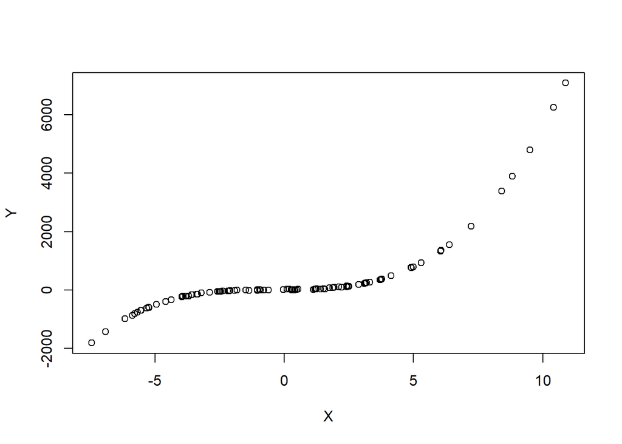

```r
true_beta_0 = 8
true_beta_1 = 5
true_beta_2 = 5
true_beta_3 = 5

x<-rnorm(100, 0, 5)
y <- true_beta_3 * x^3 + true_beta_2 * x^2 + true_beta_1 * x + true_beta_0 + rnorm(50,0,10)

df <- data.frame(X = x,Y = y)
plot(df$X, df$Y, xlab="X", ylab="Y")
```

```r
fit <- lm(Y ~ X , df)
summary(fit)
```

```
##
## Call:
## lm(formula = Y ~ X, data = df)
##
## Residuals:
##    Min     1Q Median     3Q    Max
## -824.0 -575.1  -35.4  402.2 4136.2
##
## Coefficients:
##             Estimate Std. Error t value Pr(>|t|)
## (Intercept)   247.32      77.97   3.172  0.00202 **
## X             248.80      19.50  12.761  < 2e-16 ***
## ---
## Signif. codes:  0 '***' 0.001 '**' 0.01 '*' 0.05 '.' 0.1 ' ' 1
##
## Residual standard error: 779.7 on 98 degrees of freedom
## Multiple R-squared:  0.6243, Adjusted R-squared:  0.6204
## F-statistic: 162.8 on 1 and 98 DF,  p-value: < 2.2e-16
```

```r
fit2 <- lm(Y ~ X + I(X^2) + I(X^3) , df)
summary(fit2)
```

```
##
## Call:
## lm(formula = Y ~ X + I(X^2) + I(X^3), data = df)
##
## Residuals:
##      Min       1Q   Median       3Q      Max
## -23.9080  -7.1401  -0.7005   6.7650  24.5352
##
## Coefficients:
##             Estimate Std. Error t value Pr(>|t|)
## (Intercept)  8.62060    1.31093   6.576 2.52e-09 ***
## X            5.95324    0.45256  13.155  < 2e-16 ***
## I(X^2)       5.11599    0.06747  75.824  < 2e-16 ***
## I(X^3)       4.97791    0.01000 497.557  < 2e-16 ***
## ---
## Signif. codes:  0 '***' 0.001 '**' 0.01 '*' 0.05 '.' 0.1 ' ' 1
##
## Residual standard error: 9.74 on 96 degrees of freedom
## Multiple R-squared:  0.9999, Adjusted R-squared:  0.9999
## F-statistic: 5.571e+05 on 3 and 96 DF,  p-value: < 2.2e-16
```

We can see that when the true relationship is cubic, the simple linear regresson is doing badly because although we know tha the term $x$ is significant, the residual is very large. When we are fitting a cubic polynomial to the data, all terms are significant and the residual is small, we know that the true relationship is roughly cubic. The p-value for the whole model is the same.

Case 3: When the true relationship is more complex than cubic (i.e. 4th power, 5th power…):

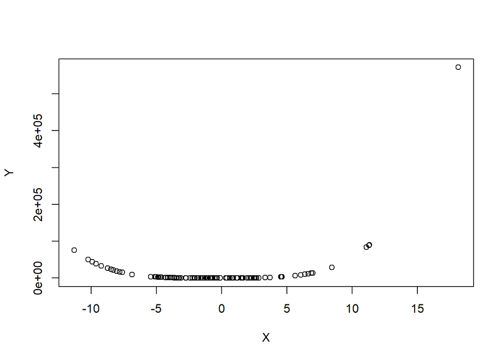

```r
true_beta_0 = 8
true_beta_1 = 5
true_beta_2 = 5
true_beta_3 = 5
true_beta_4 = 5

x<-rnorm(100, 0, 5)
y <- true_beta_4 * x^4 + true_beta_3 * x^3 + true_beta_2 * x^2 + true_beta_1 * x + true_beta_0 + rnorm(50,0,10)

df <- data.frame(X = x,Y = y)
plot(df$X, df$Y, xlab="X", ylab="Y")
```

```r
fit <- lm(Y ~ X , df)
summary(fit)
```

```
##
## Call:
## lm(formula = Y ~ X, data = df)
##
## Residuals:
##    Min     1Q Median     3Q    Max
## -34229 -23192 -10744   3743 477824
##
## Coefficients:
##             Estimate Std. Error t value Pr(>|t|)
## (Intercept)    16101       5581   2.885 0.004812 **
## X               4308       1088   3.958 0.000143 ***
## ---
## Signif. codes:  0 '***' 0.001 '**' 0.01 '*' 0.05 '.' 0.1 ' ' 1
##
## Residual standard error: 55410 on 98 degrees of freedom
## Multiple R-squared:  0.1378, Adjusted R-squared:  0.129
## F-statistic: 15.67 on 1 and 98 DF,  p-value: 0.0001431
```

```r
fit2 <- lm(Y ~ X + I(X^2) + I(X^3) , df)
summary(fit2)
```

```
##
## Call:
## lm(formula = Y ~ X + I(X^2) + I(X^3), data = df)
##
## Residuals:
##    Min     1Q Median     3Q    Max
## -43009  -9195   2275   9664  51143
##
## Coefficients:
##              Estimate Std. Error t value Pr(>|t|)
## (Intercept) -7660.559   1694.730  -4.520 1.76e-05 ***
## X           -3121.929    442.053  -7.062 2.58e-10 ***
## I(X^2)        672.707     41.281  16.296  < 2e-16 ***
## I(X^3)         61.963      3.753  16.512  < 2e-16 ***
## ---
## Signif. codes:  0 '***' 0.001 '**' 0.01 '*' 0.05 '.' 0.1 ' ' 1
##
## Residual standard error: 13920 on 96 degrees of freedom
## Multiple R-squared:  0.9467, Adjusted R-squared:  0.9451
## F-statistic: 568.6 on 3 and 96 DF,  p-value: < 2.2e-16
```

When the true relationship is more complex than cubic, the linear model and cubic model has the same behavior, their terms are all significant but their residual are large. We know that we should keep adding more power term to the model. One thing to be noticed is that, the residual for the cubic polynomial is smaller than that of the linear model, so we know that the cubic model is a better fit for the data. The p-value for the whole model is smaller in the cubic regression model.

Conclusion:

When using hypothesis test, the cubic regressoin can always gives us more information about the true relationship between the response and the predictors. But when only look at the p-value for the entire model, it is hard to tell which model is a better fit because they both are significant (p-value < 0.05) and sometime at the same valye and sometime one is bigger than the other.